# SVAR Analysis of the Italian Electricity Market

Identification by Sign Restrictions (Kilian & Lütkepohl, 2017, Ch. 13)

Alessandro Macchi

2026-09-27

# 1 Overview

This report estimates a reduced-form VAR for the Italian electricity market and identifies structural shocks via **sign restrictions**, following Kilian & Lütkepohl (2017, Ch. 13): Haar-uniform random rotations of the Cholesky factor (via QR decomposition), an admissible-set search over the configured sign restrictions, and Fry & Pagan (2011) median-target (MT) selection for the reported impulse responses. Confidence bands come from a **frequentist** residual bootstrap (Inoue & Kilian, 2013) that re-runs the entire identification search inside every replication.

Every modeling choice below (variables, transformations, lags, restrictions, bootstrap settings) is read from `00_config.R` – that is the only file that needs editing to change the analysis.

## 1.1 Endogenous variables

```r
var_table <- purrr::map_dfr(config$variables, ~ tibble::tibble(
  id = .x$id, file = .x$file, label = .x$label,
  transform = .x$transform, role = .x$role
))
knitr::kable(var_table, caption = "Variables configured in 00_config.R")
```

Variables configured in 00_config.R

| id | file | label | transform | role |
| --- | --- | --- | --- | --- |
| pun | pun.csv | PUN (EUR/MWh) | log | endogenous |
| gas_price | ttf.csv | TTF Gas Price, Close (EUR/MWh) | log | endogenous |
| energy_consumption | energy_consumption.csv | Electricity Consumption (MWh) | log | endogenous |
| ipi | ita_ipi.csv | Italian Industrial Production Index | log | endogenous |
| res_capacity | ita_res_capacity.csv | RES Installed Capacity (MW) | level | exogenous |

# 2 Data loading

Each raw CSV is parsed with its own delimiter, date format, and decimal mark (per-variable settings in `00_config.R`), then aligned onto one common monthly grid so any month missing from a source file surfaces as an explicit `NA` instead of silently shifting the other series out of alignment.

```r
raw_data <- load_all_series(config)
cat(sprintf("Loaded %d monthly observations, %s to %s.\n",
            nrow(raw_data), min(raw_data$date), max(raw_data$date)))
```

```
## Loaded 251 monthly observations, 2005-02-01 to 2025-12-01.
```

```r
knitr::kable(head(raw_data, 6), digits = 2, caption = "Raw data (first 6 months)")
```

Raw data (first 6 months)

| date | pun | gas_price | energy_consumption | ipi | res_capacity |
| --- | --- | --- | --- | --- | --- |
| 2005-02-01 | 59.77 | 16.83 | 24893729 | 118.8 | 19501.49 |
| 2005-03-01 | 56.58 | 17.20 | 26752493 | 127.9 | 19519.98 |
| 2005-04-01 | 48.79 | 14.81 | 24582096 | 118.0 | 19538.48 |
| 2005-05-01 | 47.32 | 14.33 | 25081887 | 124.8 | 19556.97 |
| 2005-06-01 | 54.81 | 14.36 | 25633084 | 121.8 | 19575.47 |
| 2005-07-01 | 65.25 | 15.54 | 27483674 | 131.8 | 19593.96 |

```r
## One look for every figure in this report: colours from grDevices'
## Okabe-Ito colourblind-safe palette, no plot box, horizontal tick labels,
## plain left-aligned titles, and a light horizontal grid behind the data.
## `theme_par(...)` takes the per-figure par settings (mfrow, mar) too, so
## each plotting chunk sets its layout and the style in one call.
pal <- grDevices::palette.colors(NULL, "Okabe-Ito")

theme_par <- function(...) {
  par(bty = "n", las = 1, tcl = -0.25, mgp = c(2.4, 0.5, 0), adj = 0,
      font.main = 1, cex.main = 1.05, col.main = "grey15",
      col.axis = "grey35", col.lab = "grey30", fg = "grey65", ...)
}

grid_h <- function() grid(nx = NA, ny = NULL, col = "grey92", lty = 1, lwd = 0.7)

#' Legend in the figure's top outer margin. The FEVD and historical
#' decomposition panels are filled edge to edge, so a legend placed inside any
#' one of them sits on the data. Pair with `oma = c(0, 0, 3, 0)` in the
#' theme_par() call so the outer margin exists to draw into.
top_legend <- function(...) {
  legend(grconvertX(0.5, "ndc", "user"), grconvertY(1, "ndc", "user"),
         xjust = 0.5, yjust = 1, xpd = NA,
         border = NA, bty = "n", cex = 0.85, ...)
}

#' Draw one plot into `plots_dir/<variable id>/<name>.png` instead of the
#' report -- the report shows the combined grids, the per-variable files are
#' for use outside it.
save_plot <- function(id, name, draw) {
  dir <- file.path(config$paths$plots_dir, id)
  dir.create(dir, showWarnings = FALSE, recursive = TRUE)
  grDevices::png(file.path(dir, paste0(name, ".png")),
                 width = 7, height = 4.5, units = "in", res = 150)
  on.exit(grDevices::dev.off())
  theme_par(mar = c(3.5, 4, 3, 1))
  draw()
}

plot_series <- function(v) {
  plot(raw_data$date, raw_data[[v$id]], type = "l", col = pal[["blue"]], lwd = 1.5,
       xlab = "", ylab = "", main = v$label, panel.first = grid_h())
}

## NA-dropping matches the unit-root tests in 03_sanity_checks.R: the common
## monthly grid pads series that start late with explicit NAs.
plot_acf  <- function(v) stats::acf(stats::na.omit(raw_data[[v$id]]), lag.max = 36,
                                    main = paste("ACF:", v$label),
                                    col = pal[["blue"]], lwd = 1.5,
                                    ci.col = pal[["vermillion"]], panel.first = grid_h())
plot_pacf <- function(v) stats::pacf(stats::na.omit(raw_data[[v$id]]), lag.max = 36,
                                     main = paste("PACF:", v$label),
                                     col = pal[["blue"]], lwd = 1.5,
                                     ci.col = pal[["vermillion"]], panel.first = grid_h())
```

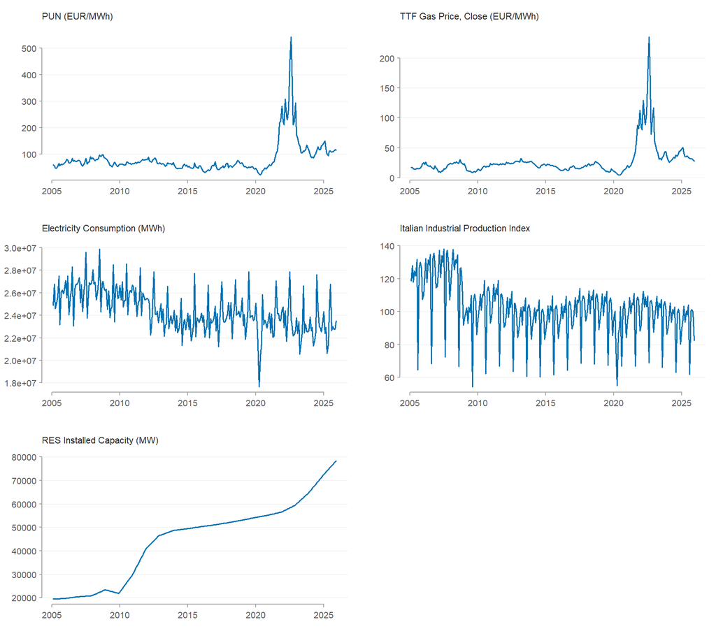

```r
theme_par(mfrow = c(ceiling(length(config$variables) / 2), 2), mar = c(3, 4, 3, 1))
for (v in config$variables) plot_series(v)

for (v in config$variables) save_plot(v$id, "timeseries", function() plot_series(v))
```

## 2.1 Autocorrelation

Sample ACF and PACF of each raw series, over 36 monthly lags. The slow decay in the level series is what the transformations in `00_config.R` address; spikes at lags 12, 24 and 36 (clearest in electricity consumption) are the calendar seasonality the monthly dummies absorb.

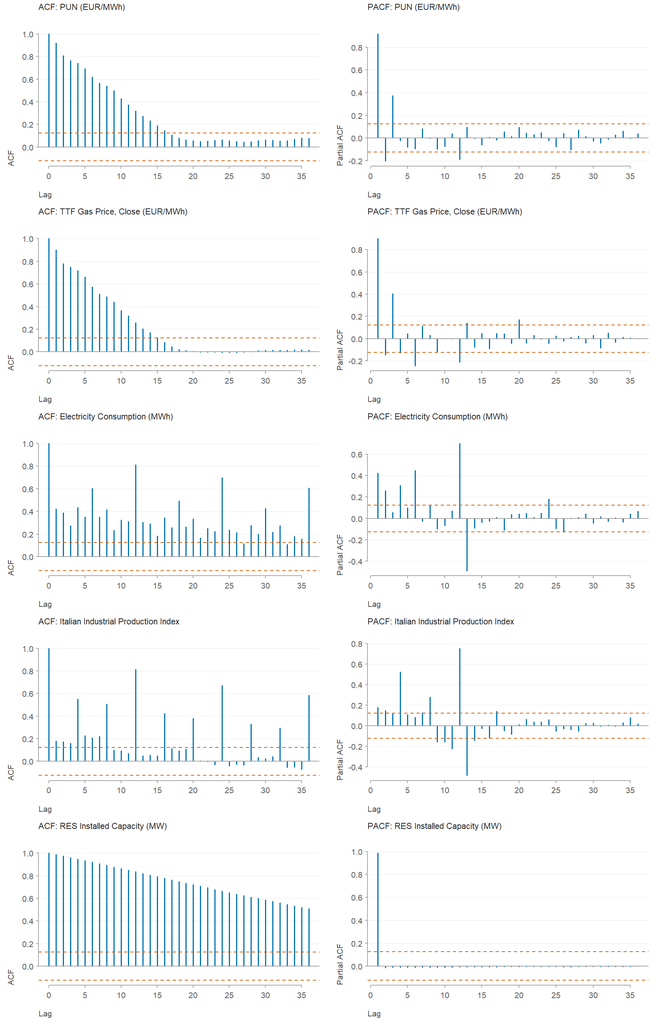

```r
## Wider top/bottom margins than the raw-series grid: with 12 panels the
## default c(3, 4, 2, 1) leaves too little room and each panel title lands on
## the "Lag" axis of the panel above it.
theme_par(mfrow = c(length(config$variables), 2), mar = c(4, 4, 3, 1))
for (v in config$variables) {
  plot_acf(v)
  plot_pacf(v)
}
```

```r
for (v in config$variables) {
  save_plot(v$id, "acf", function() plot_acf(v))
  save_plot(v$id, "pacf", function() plot_pacf(v))
}
```

# 3 Transformations

Each variable’s `transform` field (`level` / `log` / `diff` / `logdiff`) is applied generically – switching a transformation is a one-line change in `00_config.R` and never touches this code.

```r
model_data <- transform_data(raw_data, config$variables)
knitr::kable(head(model_data, 6), digits = 4, caption = "Transformed data (first 6 months)")
```

Transformed data (first 6 months)

| date | pun | gas_price | energy_consumption | ipi | res_capacity |
| --- | --- | --- | --- | --- | --- |
| 2005-02-01 | 4.0906 | 2.8233 | 17.0301 | 4.7774 | 19501.49 |
| 2005-03-01 | 4.0357 | 2.8451 | 17.1021 | 4.8512 | 19519.98 |
| 2005-04-01 | 3.8876 | 2.6952 | 17.0175 | 4.7707 | 19538.48 |
| 2005-05-01 | 3.8569 | 2.6620 | 17.0377 | 4.8267 | 19556.97 |
| 2005-06-01 | 4.0038 | 2.6642 | 17.0594 | 4.8024 | 19575.47 |
| 2005-07-01 | 4.1782 | 2.7435 | 17.1291 | 4.8813 | 19593.96 |

# 4 VAR estimation

Variables are split into endogenous/exogenous automatically from each variable’s `role` in config. Eleven monthly seasonal dummies (Feb-Dec; Jan is the reference month) are always appended to the exogenous block to control for calendar seasonality. The lag order follows `config$lag_selection` (`fixed` or `auto` via `vars::VARselect()`).

```r
var_out <- estimate_var(model_data, config)
cat(sprintf("Lag order p = %d (method: %s). Estimation sample: %d observations.\n",
            var_out$p, config$lag_selection$method, nrow(var_out$endo) - var_out$p))
```

```
## Lag order p = 12 (method: fixed). Estimation sample: 239 observations.
```

# 5 Diagnostics

Per the thesis’s model-validation requirements: unit-root tests (ADF, KPSS), a Johansen cointegration test, VAR residual diagnostics (autocorrelation, normality), and companion-matrix stability. One compact table per check – read the statistics against the reported critical values / p-values directly, no automatic interpretation.

```r
knitr::kable(unit_root_table(raw_data, config$variables, space = "level"), digits = 3,
             caption = "Unit-root tests, level (ADF H0: unit root; KPSS H0: stationary; p < 0.05 rejects H0)")
```

Unit-root tests, level (ADF H0: unit root; KPSS H0: stationary; p < 0.05 rejects H0)

| variable | adf_stat | adf_p | kpss_stat | kpss_p |
| --- | --- | --- | --- | --- |
| pun | -2.076 | 0.255 | 0.901 | 0.01 |
| gas_price | -3.592 | 0.007 | 0.938 | 0.01 |
| energy_consumption | -1.424 | 0.571 | 3.002 | 0.01 |
| ipi | -2.526 | 0.111 | 1.855 | 0.01 |
| res_capacity | -0.269 | 0.926 | 3.959 | 0.01 |

```r
knitr::kable(unit_root_table(raw_data, config$variables, space = "transform"), digits = 3,
             caption = "Unit-root tests, after transform (ADF H0: unit root; KPSS H0: stationary; p < 0.05 rejects H0)")
```

Unit-root tests, after transform (ADF H0: unit root; KPSS H0: stationary; p < 0.05 rejects H0)

[output not shown]

## 5.1 Deterministic components and unit roots

```r
stationarity <- stationarity_table(raw_data, config)
knitr::kable(stationarity, digits = 3, caption = stationarity_note(stationarity))
```

Unit-root tests on deterministic-adjusted series. Every cell is the test statistic with its p-value in parentheses, and the two tests point in opposite directions: ADF H0 is a unit root, so p < 0.05 favours stationarity, while KPSS H0 is stationarity, so p < 0.05 favours a unit root. An I(1) series therefore shows adf_level not significant and kpss_level significant, with the _diff columns (the same two tests on the first difference) reversing both. Terms removed before testing, by row: pun = const; gas_price = const; energy_consumption = const + season; ipi = const + season – const is the regression intercept, trend a linear trend, season 11 centred monthly dummies (Feb-Dec, each minus 1/12). ADF uses type = trend where a trend was removed and type = drift otherwise, searching up to 12 augmentation lags by AIC; its p comes from MacKinnon’s response surface. KPSS uses type = mu at the short and long Newey-West bandwidths; its p is interpolated from tabulated critical values and so is bounded to [0.01, 0.10]. Zivot-Andrews is in the next table.

| variable | n | deterministics | adf_level | kpss_level_short | kpss_level_long | adf_diff | kpss_diff_short | kpss_diff_long |
| --- | --- | --- | --- | --- | --- | --- | --- | --- |
| pun | 251 | const | -2.076 (0.255) | 0.901 (<0.01) | 0.400 (0.077) | -11.620 (<0.001) | 0.047 (>0.10) | 0.044 (>0.10) |
| gas_price | 251 | const | -3.592 (0.007) | 0.938 (<0.01) | 0.440 (0.060) | -6.298 (<0.001) | 0.034 (>0.10) | 0.032 (>0.10) |
| energy_consumption | 251 | const + season | -1.423 (0.571) | 3.139 (<0.01) | 1.302 (<0.01) | -6.164 (<0.001) | 0.026 (>0.10) | 0.042 (>0.10) |
| ipi | 251 | const + season | -2.494 (0.118) | 2.013 (<0.01) | 0.886 (<0.01) | -5.340 (<0.001) | 0.027 (>0.10) | 0.044 (>0.10) |

```r
knitr::kable(za_table(raw_data, config), digits = 3,
             caption = "Zivot-Andrews, endogenous level shift (H0: unit root with no break)")
```

Zivot-Andrews, endogenous level shift (H0: unit root with no break)

| variable | statistic | cv_1pct | cv_5pct | cv_10pct | break_date | break_fraction |
| --- | --- | --- | --- | --- | --- | --- |
| pun | -5.887 | -5.34 | -4.8 | -4.58 | 2021-06-01 | 0.785 |
| gas_price | -5.495 | -5.34 | -4.8 | -4.58 | 2021-03-01 | 0.773 |

```r
knitr::kable(johansen_test(raw_data, config$variables, var_out$p), digits = 3,
             caption = "Johansen trace test (H0: cointegration rank <= r), 5% critical value")
```

Johansen trace test (H0: cointegration rank <= r), 5% critical value

| rank | statistic | cv_5pct |
| --- | --- | --- |
| r <= 3 | 3.975 | 9.24 |
| r <= 2 | 13.778 | 19.96 |
| r <= 1 | 24.345 | 34.91 |
| r = 0 | 55.315 | 53.12 |

```r
knitr::kable(residual_diagnostics(var_out$fit, var_out$p), digits = 3,
             caption = "VAR residual diagnostics")
```

VAR residual diagnostics

| test | statistic | df | p_value |
| --- | --- | --- | --- |
| Portmanteau (LM) | 234.193 | 192 | 0.02 |
| Jarque-Bera | 364.254 | 8 | 0.00 |

```r
knitr::kable(stability_table(var_out$fit), digits = 3,
             caption = "Companion-matrix root moduli (sorted descending)")
```

Companion-matrix root moduli (sorted descending)

| 1 | 2 | 3 | 4 | 5 | 6 |
| --- | --- | --- | --- | --- | --- |
| 0.965 | 0.965 | 0.961 | 0.955 | 0.955 | 0.946 |
| 0.946 | 0.909 | 0.906 | 0.906 | 0.905 | 0.905 |
| 0.904 | 0.904 | 0.902 | 0.902 | 0.893 | 0.893 |
| 0.892 | 0.892 | 0.880 | 0.880 | 0.877 | 0.877 |
| 0.875 | 0.875 | 0.872 | 0.872 | 0.865 | 0.865 |
| 0.864 | 0.864 | 0.864 | 0.864 | 0.864 | 0.859 |
| 0.859 | 0.837 | 0.837 | 0.827 | 0.827 | 0.799 |
| 0.799 | 0.714 | 0.714 | 0.714 | 0.594 | 0.015 |

# 6 Identification

Structural shocks are identified via sign restrictions read generically from `config$shocks` – adding a shock or a restriction requires no changes to `05_sign_restrictions.R`. For each of `config$identification$n_draws` Haar-uniform random rotations $Q$, the structural impact matrix $B_0 = P Q$ is checked against every configured shock’s sign restrictions; admissible draws are kept, and the **Fry-Pagan median-target** draw (the single admissible model closest to the pointwise median IRF) is reported, rather than the pointwise median itself.

```r
ident <- identify_sign_restrictions(var_out$fit, config)

cat(sprintf(
  "Acceptance rate: %.2f%% (%d / %d rotations admissible).\n",
  100 * ident$draws$acceptance_rate, ident$draws$n_accepted, ident$draws$n_draws
))
```

```
## Acceptance rate: 0.18% (549 / 300000 rotations admissible).
```

The acceptance rate is a diagnostic of how informative the restrictions are: a low rate means the restrictions rule out most of the rotation space (informative, but a non-refutability check worth keeping in mind); a rate near 100% means the restrictions barely bind.

```r
restr_table <- purrr::map_dfr(config$shocks, function(s) {
  purrr::imap_dfr(s$restrictions, function(r, var_id) {
    tibble::tibble(shock = s$name, variable = var_id, sign = r$sign,
                    horizons = paste(range(r$horizons), collapse = ":"))
  })
})
knitr::kable(restr_table, caption = "Configured sign restrictions")
```

Configured sign restrictions

| shock | variable | sign | horizons |
| --- | --- | --- | --- |
| Industrial_Demand_Shock | pun | + | 0:0 |
| Industrial_Demand_Shock | gas_price | + | 0:0 |
| Industrial_Demand_Shock | ipi | + | 0:0 |
| Industrial_Demand_Shock | energy_consumption | + | 0:0 |
| Non-Industrial_Demand_Shock | pun | + | 0:0 |
| Non-Industrial_Demand_Shock | gas_price | + | 0:0 |
| Non-Industrial_Demand_Shock | ipi | - | 0:0 |
| Non-Industrial_Demand_Shock | energy_consumption | + | 0:0 |
| Gas-Specific_Shock | pun | + | 0:0 |
| Gas-Specific_Shock | gas_price | + | 0:0 |
| Gas-Specific_Shock | ipi | - | 0:0 |
| Gas-Specific_Shock | energy_consumption | - | 0:0 |

# 7 Bootstrap

Frequentist confidence bands (Inoue & Kilian, 2013): the reduced-form VAR residuals are resampled, the sample is rebuilt recursively, the VAR is re-estimated, and the **entire identification search above is re-run** inside every replication – not just a coefficient resample.

```r
boot_out <- run_bootstrap(var_out$fit, var_out$endo, var_out$exo, var_out$p, config)

cat(sprintf(
  "Bootstrap: %d replications, %d succeeded, %d found no admissible rotation.\n",
  boot_out$n_boot, boot_out$n_ok, boot_out$n_failed
))
```

```
## Bootstrap: 2000 replications, 2000 succeeded, 0 found no admissible rotation.
```

```r
cat(sprintf(
  "Mean acceptance rate across successful replications: %.2f%%.\n",
  100 * mean(boot_out$boot_acceptance_rates)
))
```

```
## Mean acceptance rate across successful replications: 0.19%.
```

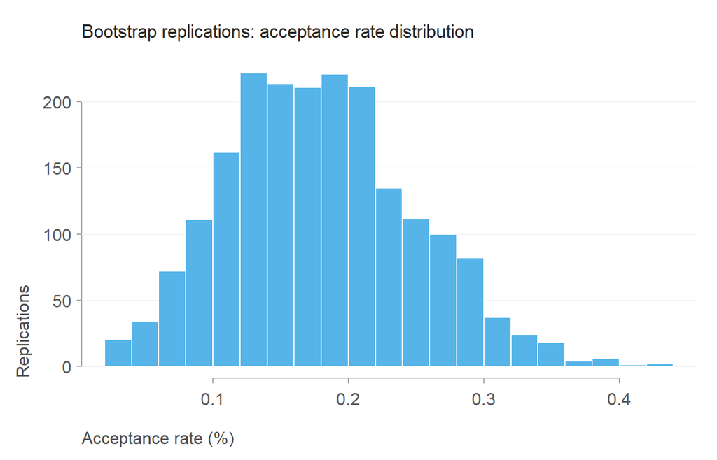

```r
theme_par(mar = c(4, 4, 3, 1))
h <- hist(100 * boot_out$boot_acceptance_rates, breaks = 15, plot = FALSE)
## Drawn twice so the grid sits behind the bars: plot.histogram() has no
## panel.first.
plot(h, col = NA, border = NA, main = "Bootstrap replications: acceptance rate distribution",
     xlab = "Acceptance rate (%)", ylab = "Replications")
grid_h()
plot(h, col = pal[["skyblue"]], border = "white", add = TRUE)
```

# 8 Results

Median-target impulse responses with 68% bootstrap confidence bands. Every endogenous variable enters the VAR in logs, so the responses are percent deviations from baseline to a one-standard-deviation structural shock (log points x 100; exactly, 100(e^theta - 1)).

```r
plot_irf_grid <- function(mt_irf, bands, var_names, shock_names, var_labels) {
  n_shocks <- length(shock_names)
  n_vars <- length(var_names)
  h <- seq_len(dim(mt_irf)[3]) - 1

  ## Bottom margin 4, not 3: the last row carries the "Horizon (months)"
  ## label at mgp[1] = 2.4 lines, which a 3-line margin clips.
  old_par <- theme_par(mfrow = c(n_vars, n_shocks), mar = c(4, 4, 3, 1))
  on.exit(par(old_par))

  for (v in seq_len(n_vars)) {
    for (s in seq_len(n_shocks)) {
      ## All endogenous variables enter the VAR in logs, so the responses are
      ## log points; x100 reads them as percent deviations from baseline.
      point <- 100 * mt_irf[v, s, ]
      lo <- 100 * bands$lower[v, s, ]
      hi <- 100 * bands$upper[v, s, ]

      plot(h, point, type = "n", ylim = range(c(point, lo, hi), na.rm = TRUE),
           xlab = if (v == n_vars) "Horizon (months)" else "",
           ylab = paste0(var_labels[v], " (%)"),
           main = if (v == 1) gsub("_", " ", shock_names[s]) else "",
           panel.first = grid_h())
      polygon(c(h, rev(h)), c(lo, rev(hi)),
              col = grDevices::adjustcolor(pal[["blue"]], alpha.f = 0.18), border = NA)
      abline(h = 0, lty = 2, col = "grey55")
      lines(h, point, col = pal[["blue"]], lwd = 2)
    }
  }
}

## config labels carry the RAW series' units ("PUN (EUR/MWh)"), which are wrong
## on an IRF axis: the responses are percent deviations, not levels. Strip the
## trailing unit parenthesis -- plot_irf_grid() appends "(%)" instead. Only the
## IRF grid uses these; the raw-series and ACF panels read v$label directly.
var_labels <- sub("\\s*\\(.*\\)$", "", purrr::map_chr(config$variables, "label"))
names(var_labels) <- purrr::map_chr(config$variables, "id")
```

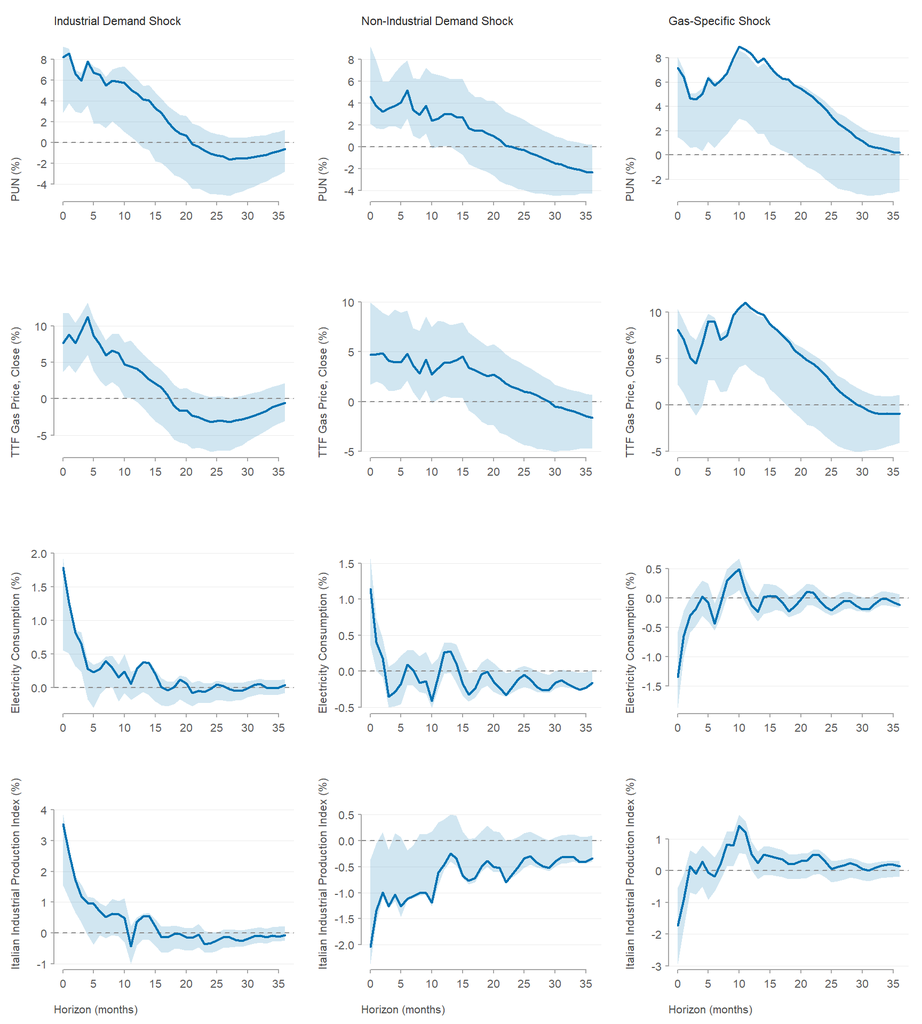

```r
plot_irf_grid(ident$mt$mt_irf, boot_out$bands, ident$var_names, ident$shock_names,
              var_labels[ident$var_names])
```

## 8.1 Variance decomposition

Share of each variable’s h-step forecast error variance attributable to the identified shocks, for the same Fry-Pagan median-target model as the impulse responses above. Horizons are months after impact, so h = 0 is the impact period. Identification is **partial** – only the shocks in `config$shocks` are pinned down – so the denominator is the full reduced-form forecast error variance implied by $\Sigma_u$, not the sum over the identified columns of $B_0$. The identified shares consequently sum to less than one, and the `unidentified` column is the remainder left to the shocks the sign restrictions do not identify. It is reported as-is: rescaling the shares to sum to one would claim an identification this design does not deliver.

Brackets are 68% pointwise percentile bands over the same pooled bootstrap draws as the IRF bands – the FEVD is computed inside each replication, so no second bootstrap pass is run.

```r
fevd_mt <- fevd_median_target(var_out$fit, ident, config$identification$horizon)
fevd_names <- c(gsub("_", " ", ident$shock_names), "Unidentified")

fevd_tbl <- purrr::imap_dfr(config$fevd$horizons, function(h, k) {
  tbl <- tibble::tibble(horizon = h, variable = unname(var_labels[ident$var_names]))
  for (b in seq_along(fevd_names)) {
    tbl[[fevd_names[b]]] <- sprintf("%.2f [%.2f, %.2f]", fevd_mt[, b, h + 1],
                                     boot_out$fevd_bands$lower[, b, k],
                                     boot_out$fevd_bands$upper[, b, k])
  }
  tbl
})
knitr::kable(fevd_tbl, caption = paste0(
  "Forecast error variance decomposition, median-target model, with ",
  sprintf("%.0f%%", 100 * config$bootstrap$conf_level), " bootstrap bands"))
```

Forecast error variance decomposition, median-target model, with 68% bootstrap bands

| horizon | variable | Industrial Demand Shock | Non-Industrial Demand Shock | Gas-Specific Shock | Unidentified |
| --- | --- | --- | --- | --- | --- |
| 1 | PUN | 0.52 [0.09, 0.61] | 0.13 [0.03, 0.53] | 0.34 [0.02, 0.42] | 0.02 [0.01, 0.39] |
| 1 | TTF Gas Price, Close | 0.32 [0.09, 0.65] | 0.10 [0.02, 0.44] | 0.27 [0.02, 0.45] | 0.31 [0.01, 0.43] |
| 1 | Electricity Consumption | 0.56 [0.08, 0.61] | 0.17 [0.02, 0.36] | 0.26 [0.05, 0.53] | 0.00 [0.02, 0.42] |
| 1 | Italian Industrial Production Index | 0.64 [0.14, 0.75] | 0.20 [0.01, 0.28] | 0.13 [0.02, 0.41] | 0.03 [0.02, 0.47] |
| 6 | PUN | 0.51 [0.12, 0.59] | 0.16 [0.06, 0.52] | 0.32 [0.03, 0.38] | 0.02 [0.03, 0.36] |
| 6 | TTF Gas Price, Close | 0.38 [0.12, 0.65] | 0.10 [0.03, 0.42] | 0.26 [0.04, 0.40] | 0.25 [0.03, 0.41] |
| 6 | Electricity Consumption | 0.56 [0.13, 0.56] | 0.16 [0.06, 0.31] | 0.23 [0.08, 0.46] | 0.05 [0.07, 0.39] |
| 6 | Italian Industrial Production Index | 0.58 [0.16, 0.65] | 0.28 [0.05, 0.32] | 0.09 [0.05, 0.32] | 0.06 [0.07, 0.45] |
| 12 | PUN | 0.41 [0.09, 0.54] | 0.13 [0.05, 0.48] | 0.45 [0.06, 0.47] | 0.01 [0.03, 0.35] |
| 12 | TTF Gas Price, Close | 0.31 [0.10, 0.56] | 0.09 [0.04, 0.41] | 0.40 [0.08, 0.47] | 0.19 [0.04, 0.37] |
| 12 | Electricity Consumption | 0.53 [0.15, 0.50] | 0.17 [0.08, 0.30] | 0.25 [0.12, 0.44] | 0.06 [0.09, 0.37] |
| 12 | Italian Industrial Production Index | 0.48 [0.16, 0.54] | 0.31 [0.06, 0.31] | 0.16 [0.12, 0.34] | 0.06 [0.09, 0.40] |
| 24 | PUN | 0.28 [0.11, 0.45] | 0.09 [0.07, 0.44] | 0.48 [0.08, 0.48] | 0.14 [0.06, 0.37] |
| 24 | TTF Gas Price, Close | 0.23 [0.11, 0.47] | 0.10 [0.06, 0.38] | 0.44 [0.11, 0.44] | 0.23 [0.06, 0.37] |
| 24 | Electricity Consumption | 0.48 [0.16, 0.46] | 0.18 [0.10, 0.30] | 0.23 [0.13, 0.41] | 0.11 [0.12, 0.36] |
| 24 | Italian Industrial Production Index | 0.44 [0.17, 0.50] | 0.33 [0.08, 0.32] | 0.16 [0.12, 0.33] | 0.07 [0.11, 0.38] |
| 36 | PUN | 0.24 [0.12, 0.42] | 0.09 [0.09, 0.42] | 0.41 [0.09, 0.44] | 0.25 [0.08, 0.37] |
| 36 | TTF Gas Price, Close | 0.21 [0.11, 0.46] | 0.08 [0.07, 0.38] | 0.38 [0.11, 0.42] | 0.32 [0.07, 0.38] |
| 36 | Electricity Consumption | 0.45 [0.16, 0.44] | 0.20 [0.11, 0.31] | 0.23 [0.14, 0.40] | 0.12 [0.12, 0.35] |
| 36 | Italian Industrial Production Index | 0.42 [0.18, 0.48] | 0.34 [0.09, 0.32] | 0.16 [0.13, 0.33] | 0.07 [0.11, 0.38] |

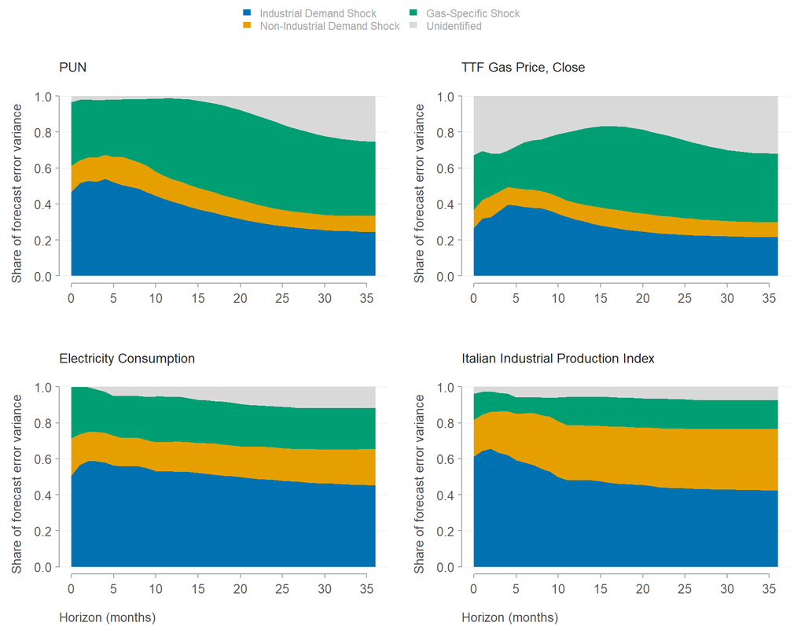

```r
#' Stacked-area FEVD, one panel per variable: the identified shocks' shares
#' stacked from the bottom and the unidentified remainder filling the gap up
#' to one, so how much of each variable the restrictions actually explain is
#' the visible grey band rather than something the reader has to subtract.
plot_fevd_grid <- function(fevd, band_names, var_labels) {
  h <- seq_len(dim(fevd)[3]) - 1
  n_vars <- dim(fevd)[1]
  cols <- c(unname(pal[c("blue", "orange", "bluishgreen", "reddishpurple")])[
    seq_len(length(band_names) - 1)], "grey85")

  old_par <- theme_par(mfrow = c(ceiling(n_vars / 2), 2), mar = c(3.5, 4, 3, 1),
                       oma = c(0, 0, 3, 0))
  on.exit(par(old_par))

  for (v in seq_len(n_vars)) {
    cum <- rbind(0, apply(fevd[v, , ], 2, cumsum))
    plot(h, cum[nrow(cum), ], type = "n", ylim = c(0, 1),
         xlab = if (v > n_vars - 2) "Horizon (months)" else "",
         ylab = "Share of forecast error variance",
         main = var_labels[v], panel.first = grid_h())
    for (b in seq_along(band_names)) {
      polygon(c(h, rev(h)), c(cum[b, ], rev(cum[b + 1, ])), col = cols[b], border = NA)
    }
  }
  top_legend(legend = band_names, fill = cols, ncol = 2)
}

plot_fevd_grid(fevd_mt, fevd_names, var_labels[ident$var_names])
```

## 8.2 Historical decomposition

Where the FEVD asks how much of the *average* forecast error each shock explains, the historical decomposition asks what each shock did in each individual month of the estimation sample. It uses the same Fry-Pagan median-target model as the impulse responses and the variance decomposition above: the structural shocks are recovered by inverting that single $B_0$ through the reduced-form residuals ($\varepsilon_t = B_0^{-1} u_t$) and convolved with the structural moving-average weights $\Theta_h = \Phi_h B_0$. Nothing is re-estimated and no rotation is redrawn.

Identification is **partial** here in exactly the sense it is in the FEVD. $B_0$ is a full invertible $K \times K$ matrix, so all $K$ structural shocks are recoverable for this rotation, but only the shocks in `config$shocks` carry an economic label; the remaining columns are summed into a single `other shocks` band rather than rescaled away or dropped.

The **baseline** is everything the structural shocks do not move: the intercept, the 11 monthly seasonal dummies, the exogenous block (the `energy_crisis` dummy and `res_capacity`), and the effect of the $p$ presample values. It is therefore **not** a pure trend – in particular the energy-crisis dummy’s effect sits in the baseline, so the gas shock is credited only with what that dummy leaves unexplained, and the 2022 bars should be read against a baseline that has already shifted. Contributions of all $K$ shocks sum to the plotted deviation by construction, so the bars add up to the black line in every month.

No bootstrap bands and no per-episode contribution tables are reported for the historical decomposition: it is the point-estimate path of the median-target model.

```r
hd <- historical_decomposition(var_out, ident)
cat(sprintf("Historical decomposition over %d months, %s to %s.\n",
            nrow(hd$y_dev), min(hd$dates), max(hd$dates)))
```

```
## Historical decomposition over 239 months, 2006-02-01 to 2025-12-01.
```

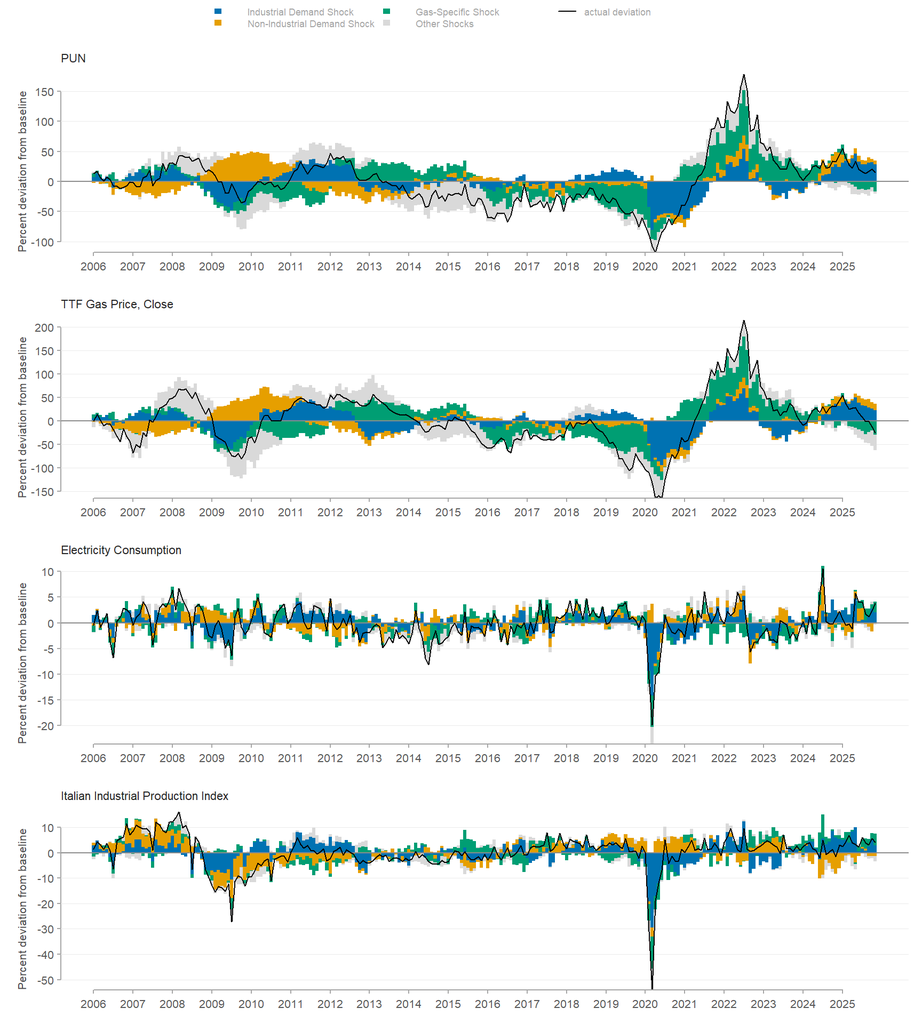

```r
#' Stacked contribution bars over time, one panel per endogenous variable,
#' with the actual deviation from baseline drawn on top in black. barplot()
#' stacks mixed-sign columns wrong (every segment is laid out from zero
#' upward, so negative contributions overwrite positive ones), so the
#' contributions are split into their positive and negative parts and drawn
#' as two stacked barplots sharing one ylim; the segments then meet at zero
#' and their net total is the black line by construction.
plot_hd_grid <- function(hd, var_labels) {
  n_shocks <- length(hd$shock_names)
  n_vars <- dim(hd$contrib)[2]
  band_names <- c(gsub("_", " ", hd$shock_names), "Other Shocks")
  ## Same shock -> colour mapping as the FEVD panels, grey for the shocks
  ## the restrictions do not identify.
  cols <- c(unname(pal[c("blue", "orange", "bluishgreen", "reddishpurple")])[
    seq_len(n_shocks)], "grey85")
  at <- seq(1, length(hd$dates), by = 12)

  old_par <- theme_par(mfrow = c(n_vars, 1), mar = c(2.5, 4.5, 2.5, 1),
                       oma = c(0, 0, 3, 0))
  on.exit(par(old_par))

  for (v in seq_len(n_vars)) {
    ## All endogenous variables enter the VAR in logs, so x100 reads the
    ## contributions as percent deviations, exactly as in the IRF grid.
    m <- 100 * t(cbind(hd$contrib[, v, seq_len(n_shocks)],
                       rowSums(hd$contrib[, v, -seq_len(n_shocks), drop = FALSE])))
    pos <- pmax(m, 0)
    neg <- pmin(m, 0)

    ## Drawn empty first so the grid sits behind the bars (barplot() has no
    ## panel.first) and to take the bar midpoints from its return value.
    bp <- barplot(pos, space = 0, col = NA, border = NA,
                  ylim = range(colSums(pos), colSums(neg)),
                  ylab = "Percent deviation from baseline", main = var_labels[v])
    grid_h()
    barplot(pos, space = 0, col = cols, border = NA, add = TRUE, axes = FALSE)
    barplot(neg, space = 0, col = cols, border = NA, add = TRUE, axes = FALSE)
    abline(h = 0, col = "grey55")
    lines(bp, 100 * hd$y_dev[, v], col = "black", lwd = 1.2)
    axis(1, at = bp[at], labels = format(hd$dates[at], "%Y"))
  }
  top_legend(legend = c(band_names, "actual deviation"),
             fill = c(cols, NA), col = "black",
             lty = c(rep(NA, length(cols)), 1), lwd = c(rep(NA, length(cols)), 1.2),
             ncol = 3)
}

plot_hd_grid(hd, var_labels[ident$var_names])
```

## 8.3 Conditional forecast

The conditional forecasts hold the reduced form and the admissible rotations **fixed** at the 2006–2025 estimates above: nothing is re-estimated and no rotation is redrawn on the 2026 data. Every series is reloaded to `cf$data_end` with the same transformations; RES installed capacity, which has no 2026 values, is carried forward by its last monthly step. The one-step-ahead forecast error of month $t$ uses the fixed coefficients and the *realised* lags, $u_t = y_t - \hat y_{t|t-1}$, and the structural shocks are $\varepsilon_t = B_0^{-1} u_t$, in standard deviations. A variable missing in the last data month is set to its expectation given that month’s observed errors, $E[u_m \mid u_o] = \Sigma_{mo} \Sigma_{oo}^{-1} u_o$: a **nowcast**, not data.

Every forward path is the zero-residual forecast from the last data month plus the effect of an $H \times K$ matrix $W$ of future structural shocks, $\sum_{s \le t} \Theta_{t-s} w_s$ – the historical decomposition’s convolution, run forward. Bands are 68% pointwise percentiles over the admissible rotations: they measure identification uncertainty alone, with the reduced form at its point estimate, and no bootstrap is run here.

```r
cf_out <- conditional_forecast(var_out, ident, hd, config)
pct_cf <- sprintf("%.0f%%", 100 * config$bootstrap$conf_level)
n_cf <- length(cf_out$dates)

cat(sprintf("Ex post: %s to %s. Forecast from %s: %s to %s (%d months).\n",
            format(min(cf_out$a_dates), "%b %Y"), format(max(cf_out$a_dates), "%b %Y"),
            format(cf_out$dates[n_cf], "%b %Y"), format(min(cf_out$fdates), "%b %Y"),
            format(max(cf_out$fdates), "%b %Y"), length(cf_out$fdates)))
```

```
## Ex post: Jan 2026 to Jul 2026. Forecast from Aug 2026: Sep 2026 to Dec 2027 (16 months).
```

```r
if (length(cf_out$nowcast) > 0) {
  cat(sprintf("Nowcast, not data (%s): %s.\n", format(cf_out$dates[n_cf], "%b %Y"),
              paste(sprintf("%s = %.1f", cf_out$nowcast, exp(cf_out$y[n_cf, cf_out$nowcast])),
                    collapse = ", ")))
}
```

```
## Nowcast, not data (Aug 2026): ipi = 63.7.
```

```r
cat(sprintf(paste("Checks, max abs error: one-step error vs VAR residual %.1e;",
                  "TTF vs target %.1e; reference path across rotations %.1e.\n"),
            cf_out$checks[[1]], cf_out$checks[[2]], cf_out$checks[[3]]))
```

```
## Checks, max abs error: one-step error vs VAR residual 1.7e-14; TTF vs target 1.5e-14; reference path across rotations 3.6e-15.
```

### 8.3.1 Ex post: the 2026 shocks

The one-step-ahead structural shocks of the months after the estimation sample in which all four variables are observed. The attack month (`cf$attack_month`) is set against March 2022 and against the distribution of $|\varepsilon|$ over the estimation sample, both for the median-target model. Switching `cf$attack_shocks` off from the attack month on removes their contribution, $\sum_{s \ge \text{attack}} \Theta_{t-s} \varepsilon_s$, from the data.

```r
knitr::kable(cf_out$shock_table, digits = 0, caption = paste0(
  "One-step-ahead structural shocks (s.d.): median-target model, ", pct_cf,
  " band over admissible rotations in brackets. Percentile: share of estimation-sample ",
  "months with a smaller |shock|, median-target model."))
```

One-step-ahead structural shocks (s.d.): median-target model, 68% band over admissible rotations in brackets. Percentile: share of estimation-sample months with a smaller |shock|, median-target model.

| Shock | Mar 2026 | Mar 2022 | Percentile of \|eps\| in sample (MT) |
| --- | --- | --- | --- |
| Industrial Demand Shock | 2.52 [1.51, 3.06] | 1.71 [0.80, 2.03] | 99 |
| Non-Industrial Demand Shock | 0.39 [-0.01, 1.86] | 0.78 [0.44, 1.79] | 37 |
| Gas-Specific Shock | 2.15 [0.80, 2.50] | 2.01 [0.92, 2.07] | 97 |
| Unlabelled | 1.64 [-1.85, 1.92] | 0.23 [-1.15, 1.14] | 95 |

```r
## Same shock -> colour mapping as the FEVD and historical-decomposition
## panels, grey for the shock the restrictions do not label.
cf_cols <- stats::setNames(
  c(unname(pal[c("blue", "orange", "bluishgreen", "reddishpurple")])[seq_along(ident$shock_names)],
    "grey85"),
  cf_out$shock_names)

#' One path with its rotation band behind it.
band_line <- function(x, mid, lo, hi, col) {
  polygon(c(x, rev(x)), c(lo, rev(hi)),
          col = grDevices::adjustcolor(col, alpha.f = 0.18), border = NA)
  lines(x, mid, col = col, lwd = 2)
}

#' One panel per structural shock: the median-target one-step shock of each
#' ex-post month (bars, s.d.) with its rotation band (whiskers). The shaded
#' month is the attack month.
plot_cf_shocks <- function(cf, cols) {
  x <- seq_along(cf$a_dates)
  a <- match(cf$attack, cf$a_dates)
  old_par <- theme_par(mfrow = c(2, 2), mar = c(3, 4, 3, 1))
  on.exit(par(old_par))

  for (j in seq_along(cf$shock_names)) {
    plot(range(x) + c(-0.5, 0.5), range(0, cf$eps$lower[, j], cf$eps$upper[, j]),
         type = "n", xaxt = "n", xlab = "", ylab = "Shock (s.d.)",
         main = gsub("_", " ", cf$shock_names[j]),
         panel.first = {
           rect(a - 0.5, -1e6, a + 0.5, 1e6, col = "grey93", border = NA)
           grid_h()
         })
    rect(x - 0.35, 0, x + 0.35, cf$eps$mt[, j], col = cols[j], border = NA)
    arrows(x, cf$eps$lower[, j], x, cf$eps$upper[, j], angle = 90, code = 3,
           length = 0.03, col = "grey30")
    abline(h = 0, col = "grey55")
    axis(1, at = x, labels = format(cf$a_dates, "%b"))
  }
}

#' One forward panel: the reference path dashed and each of `readings` with
#' its rotation band, all from the origin month. PUN and TTF in EUR/MWh after
#' the observed months since Jan 2025; consumption and IPI in % (100 x log)
#' deviation from the reference path.
plot_cf_panel <- function(cf, v, readings, cols, main) {
  n <- length(cf$dates)
  xf <- c(cf$dates[n], cf$fdates)
  level <- v %in% c("pun", "gas_price")
  past <- level & cf$dates >= as.Date("2025-01-01")
  path <- function(q, r) {
    p <- q[, v, r]
    if (level) exp(c(cf$y[n, v], p)) else c(0, 100 * (p - cf$paths$mt[, v, "reference"]))
  }

  plot(range(cf$dates[past], xf),
       range(exp(cf$y[past, v]), path(cf$paths$mt, "reference"),
             sapply(readings, path, q = cf$paths$lower),
             sapply(readings, path, q = cf$paths$upper)),
       type = "n", xlab = "", ylab = if (level) "EUR/MWh" else "% deviation from reference",
       main = main, panel.first = grid_h())
  for (r in readings) {
    band_line(xf, path(cf$paths$mt, r), path(cf$paths$lower, r), path(cf$paths$upper, r),
              cols[[r]])
  }
  ## Explicit black: theme_par()'s `fg` also sets the default line colour.
  lines(xf, path(cf$paths$mt, "reference"), lty = 2, lwd = 1.5, col = "black")
  if (level) lines(cf$dates[past], exp(cf$y[past, v]), lwd = 1.5, col = "black")
}
```

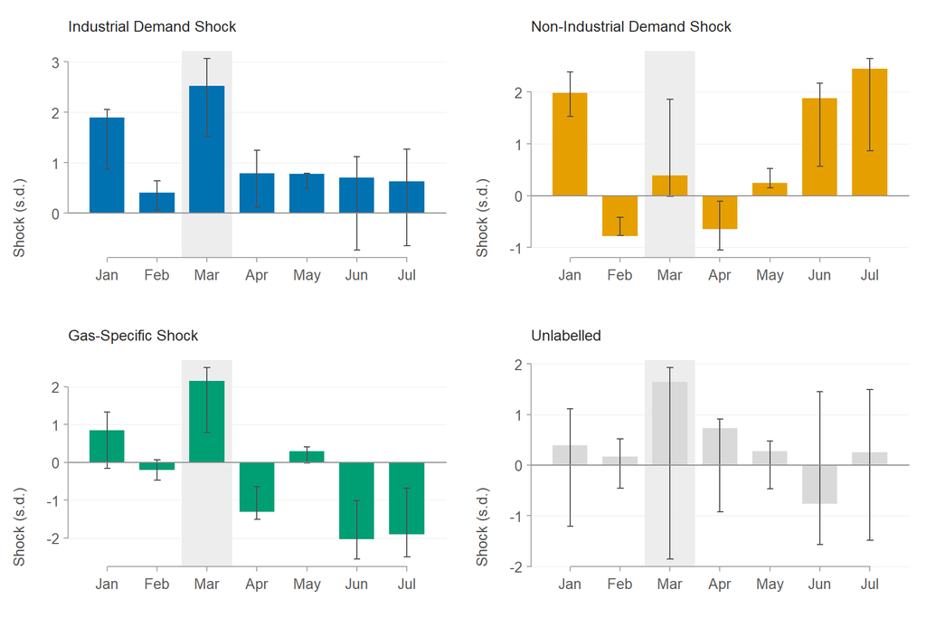

```r
plot_cf_shocks(cf_out, cf_cols)
```

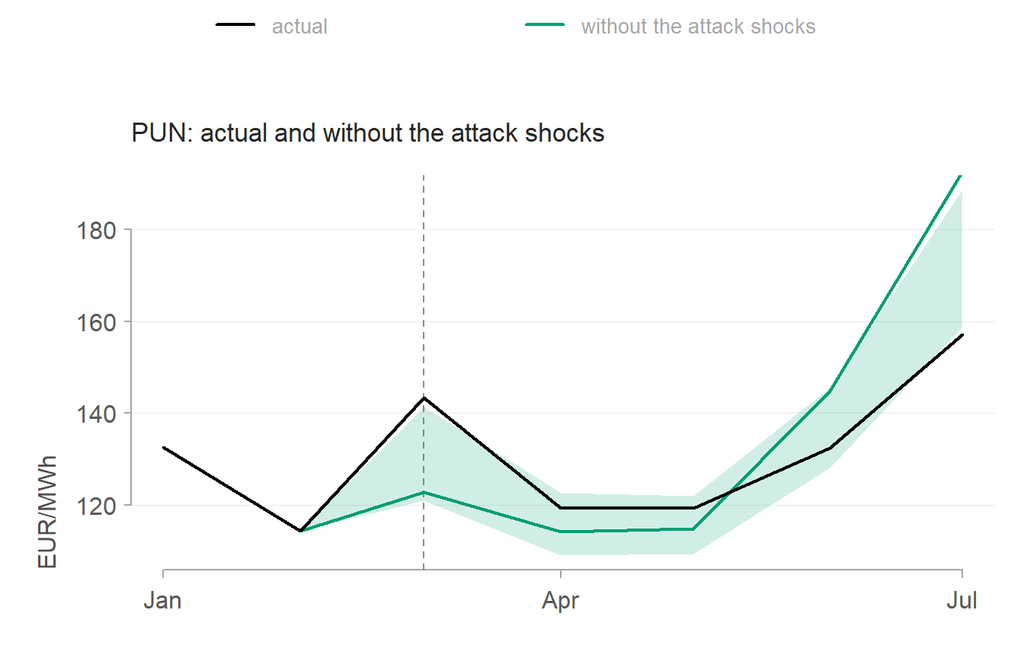

```r
cf_col <- cf_cols[[config$cf$attack_shocks[1]]]
theme_par(mar = c(3, 4.5, 3, 1), oma = c(0, 0, 3, 0))
with(cf_out$pun_cf, {
  plot(cf_out$a_dates, actual, type = "n", ylim = range(actual, lower, upper),
       xlab = "", ylab = "EUR/MWh", main = "PUN: actual and without the attack shocks",
       panel.first = grid_h())
  abline(v = cf_out$attack, lty = 2, col = "grey55")
  band_line(cf_out$a_dates, mt, lower, upper, cf_col)
  lines(cf_out$a_dates, actual, lwd = 2, col = "black")
})
top_legend(legend = c("actual", "without the attack shocks"), col = c("black", cf_col),
           lwd = 2, ncol = 2)
```

```r
knitr::kable(cf_out$gap_table, caption = paste0(
  "PUN (EUR/MWh) from the attack month on: actual, without the attack shocks, and their ",
  "contribution (the difference); median-target model, ", pct_cf,
  " band over admissible rotations in brackets."))
```

PUN (EUR/MWh) from the attack month on: actual, without the attack shocks, and their contribution (the difference); median-target model, 68% band over admissible rotations in brackets.

| Month | PUN actual | PUN without attack shocks | Attack contribution |
| --- | --- | --- | --- |
| Mar 2026 | 143.4 | 122.9 [121.1, 141.4] | 20.5 [2.0, 22.3] |
| Apr 2026 | 119.5 | 114.3 [109.1, 122.7] | 5.2 [-3.3, 10.3] |
| May 2026 | 119.4 | 115.0 [109.5, 122.0] | 4.4 [-2.7, 9.9] |
| Jun 2026 | 132.5 | 144.8 [128.2, 145.6] | -12.3 [-13.1, 4.3] |
| Jul 2026 | 157.0 | 192.4 [158.7, 188.5] | -35.4 [-31.5, -1.7] |

### 8.3.2 Persistence (D1)

TTF is held at its last observed level to `cf$horizon_end`, and the gap $r_t$ between that target and the zero-residual forecast is closed three ways. With all shocks free, the minimum-norm shocks $w = R'(RR')^{-1} r$ (Waggoner & Zha, 1999), where $R$ collects $\Theta_{t-s}[\text{TTF}, j]$ over months $s \le t$ and shocks $j$, give the **reference path**: the path is the same under every admissible rotation, the implied shocks are not. With one shock alone – gas-specific, or industrial demand – the shocks solve a lower-triangular system month by month, every other shock at zero. That system divides by the impact response of TTF to the shock, which the sign restriction bounds only at zero; in the admissible rotations where it is nearly zero the implied shocks explode, so a single-shock reading enters its band only in the rotations where it is numerically defined (TTF on the target and every path finite). PUN and TTF are in EUR/MWh; consumption and IPI in percent (100 x log) deviation from the reference path.

```r
cat(sprintf(paste("Single-shock readings numerically defined in %d (gas-specific) and %d",
                  "(industrial demand) of %d admissible rotations.\n"),
            cf_out$n_defined[["gas"]], cf_out$n_defined[["demand"]], cf_out$n_rotations))
```

```
## Single-shock readings numerically defined in 524 (gas-specific) and 528 (industrial demand) of 549 admissible rotations.
```

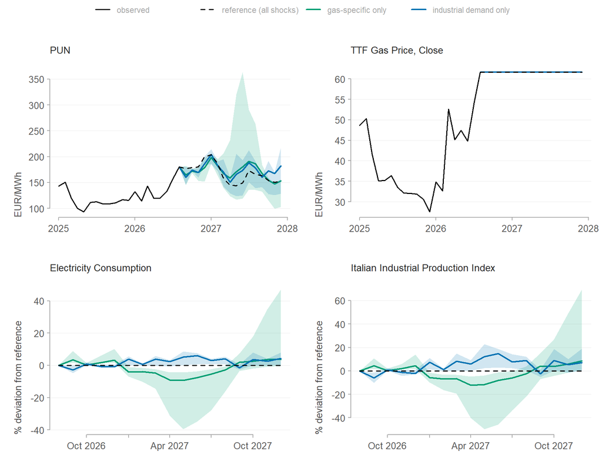

```r
d1_cols <- c(gas = cf_cols[["Gas-Specific_Shock"]], demand = cf_cols[["Industrial_Demand_Shock"]])
theme_par(mfrow = c(2, 2), mar = c(3, 4.5, 3, 1), oma = c(0, 0, 3, 0))
for (v in c("pun", "gas_price", "energy_consumption", "ipi")) {
  plot_cf_panel(cf_out, v, names(d1_cols), d1_cols, var_labels[[v]])
}
top_legend(legend = c("observed", "reference (all shocks)", "gas-specific only",
                      "industrial demand only"),
           col = c("black", "black", d1_cols), lty = c(1, 2, 1, 1), lwd = c(1.5, 1.5, 2, 2),
           ncol = 4)
```

### 8.3.3 Escalation stress test (C1) and comparison

C1 replays the median-target gas-specific shocks of `cf$c1_window`, from the month after the origin and with every other shock at zero, on top of the reference path; in the band, each rotation replays its own shocks of that window. The table compares the four forward paths.

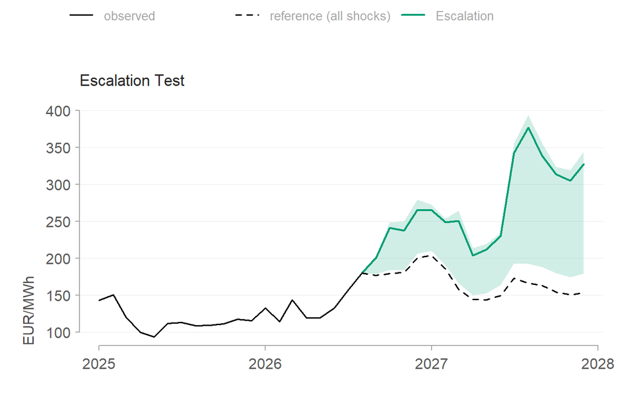

```r
c1_col <- c(c1 = cf_cols[["Gas-Specific_Shock"]])
theme_par(mar = c(3, 4.5, 3, 1), oma = c(0, 0, 3, 0))
plot_cf_panel(cf_out, "pun", "c1", c1_col, "Escalation Test")
top_legend(legend = c("observed", "reference (all shocks)", "Escalation"),
           col = c("black", "black", c1_col), lty = c(1, 2, 1), lwd = c(1.5, 1.5, 2), ncol = 3)
```

```r
knitr::kable(cf_out$comparison, caption = paste0(
  "Forward paths, ", format(min(cf_out$fdates), "%b %Y"), " to ",
  format(max(cf_out$fdates), "%b %Y"), ": median-target model, ", pct_cf,
  " band over admissible rotations in brackets (none where every rotation agrees). ",
  "PUN in EUR/MWh; IPI and consumption in % (100 x log) deviation from the reference path in ",
  format(max(cf_out$fdates), "%b %Y"), "; peak month of the median-target path."))
```

Forward paths, Sep 2026 to Dec 2027: median-target model, 68% band over admissible rotations in brackets (none where every rotation agrees). PUN in EUR/MWh; IPI and consumption in % (100 x log) deviation from the reference path in Dec 2027; peak month of the median-target path.

| Reading | PUN mean Q4 2026 | PUN mean 2027 | PUN peak | Peak month (MT) | IPI vs reference (%) | Consumption vs reference (%) | Max \|shock\| (s.d.) |
| --- | --- | --- | --- | --- | --- | --- | --- |
| Reference (all shocks) | 186.6 | 162.0 | 203.8 | Jan 2027 | 0.00 | 0.00 | 1.02 [1.04, 1.41] |
| D1 gas-specific only | 173.7 [157.3, 184.7] | 171.4 [137.9, 235.9] | 198.3 [192.9, 420.3] | Jan 2027 | 8.70 [0.72, 69.52] | 3.62 [-0.49, 47.03] | 3.24 [2.22, 29.93] |
| D1 industrial demand only | 176.9 [175.0, 184.3] | 174.6 [142.4, 203.0] | 204.6 [194.5, 244.8] | Jan 2027 | 7.23 [0.21, 18.87] | 4.29 [0.42, 7.96] | 3.07 [2.01, 8.76] |
| C1 escalation | 247.9 [191.3, 257.9] | 284.4 [177.8, 293.6] | 376.5 [210.4, 393.5] | Aug 2027 | 3.43 [-2.14, 5.55] | 0.14 [-1.74, 1.71] | 2.70 [1.69, 2.72] |

## 8.4 Saved output

```r
saveRDS(list(config = config, var_out = var_out, ident = ident, boot_out = boot_out,
             fevd_mt = fevd_mt, hd = hd, cf = cf_out),
        file.path(config$paths$output_dir, "svar_results.rds"))
cat("Saved results to", file.path(config$paths$output_dir, "svar_results.rds"), "\n")
```

```
## Saved results to output/svar_results.rds
```